# VAR model and IRF Analysis

## Bernardo Carvalho

### 07/04/2024

The following code implements the VAR model discussed in the final submission document.

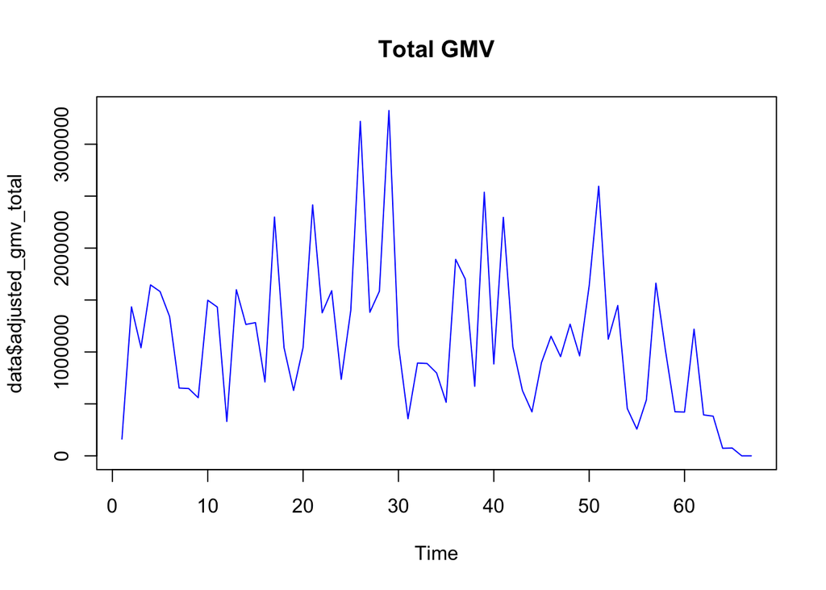

```r
# Rename columns
data$general_ads <- data$General
data$brand_ads <- data$Brand
data$display_ads <- data$Display

ts.plot(data$adjusted_gmv_total, col="blue", main="Total GMV")
```

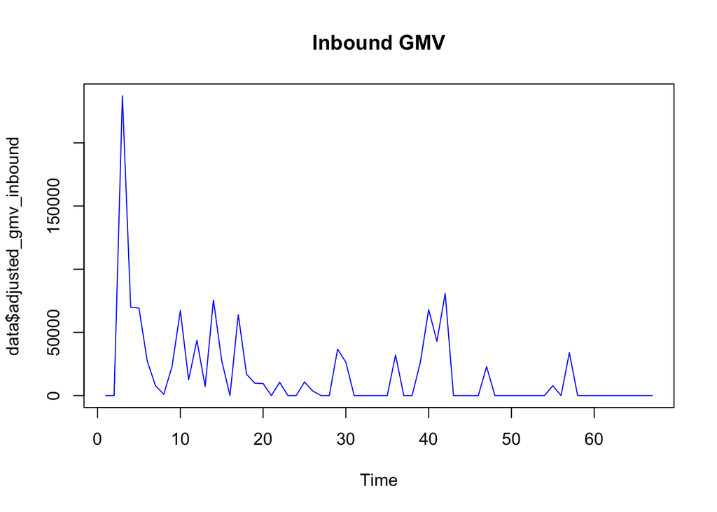

```r
ts.plot(data$adjusted_gmv_inbound, col="blue", main="Inbound GMV")
```

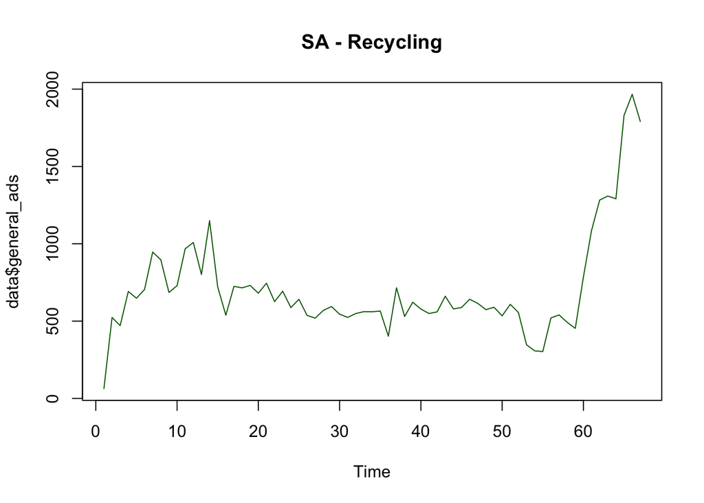

```r
ts.plot(data$general_ads, col="darkgreen", main="SA - Recycling")
```

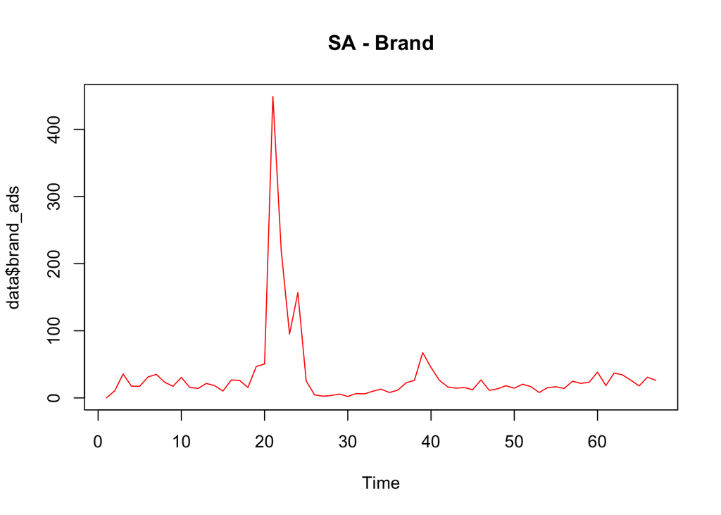

```r
ts.plot(data$brand_ads, col="red", main="SA - Brand")
```

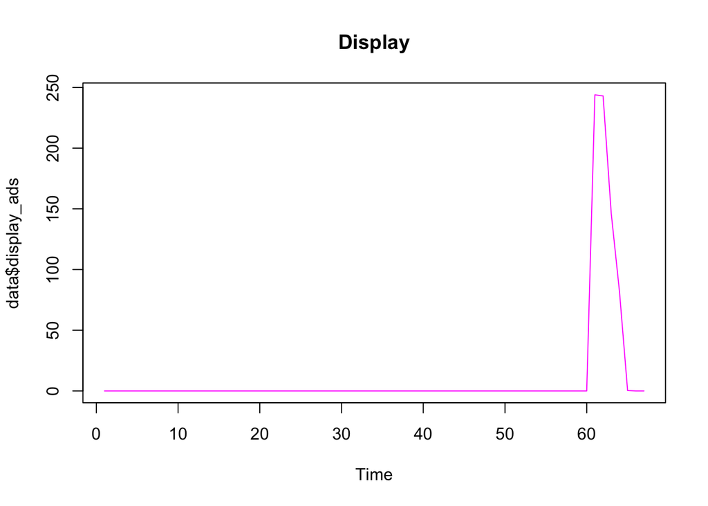

```r
ts.plot(data$display_ads, col="magenta", main="Display")
```

### Analysis Steps

- Perform unit root tests to check for non-stationary variables and take differences of the variables that are evolving.
- Estimate a vector autoregressive (VAR) model and interpret the coefficients.
- Estimate impulse response functions (IRFs) of sales to spending varialbes

**Log Transformation**

Given the high level of turbulence we observe through time-series plots, we need to take log of each variables to out the series as a first step.

```r
data$log_adjusted_gmv_total <- log(data$adjusted_gmv_total+1)
data$log_adjusted_gmv_inbound <- log(data$adjusted_gmv_inbound+1)
data$log_general_ads <- log(data$general_ads+1)
data$log_brand_ads <- log(data$brand_ads+1)
data$log_display_ads <- log(data$display_ads+1)
```

**Plot the data to observe trend**

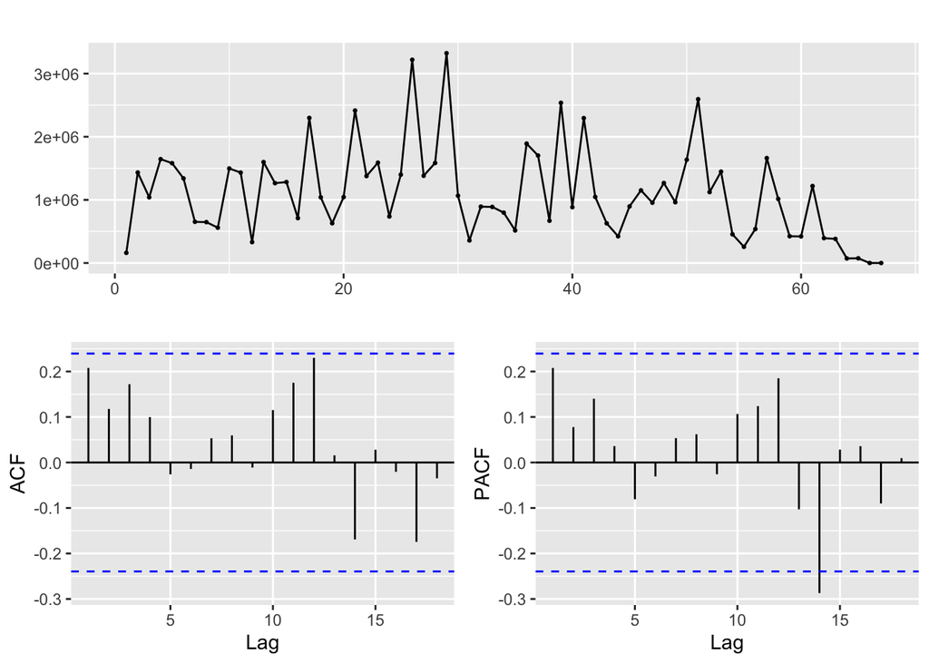

```r
Total_GMV <- ts(data$adjusted_gmv_total, frequency = 1, start = c(1, 1))

#trend plot and ACF and PACF.
ggtsdisplay(Total_GMV)
```

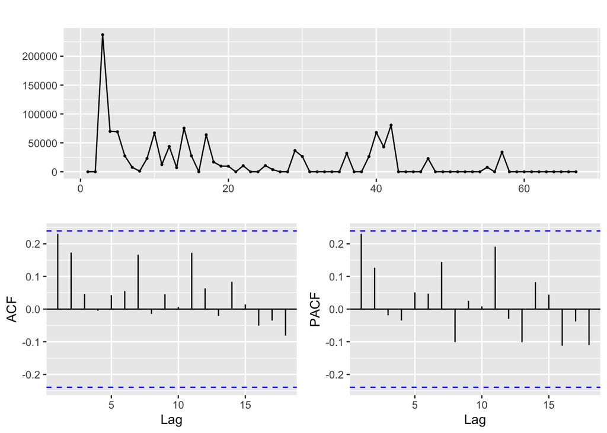

```r
Inbound_GMV <- ts(data$adjusted_gmv_inbound, frequency = 1, start = c(1, 1))

#trend plot and ACF and PACF.
ggtsdisplay(Inbound_GMV)
```

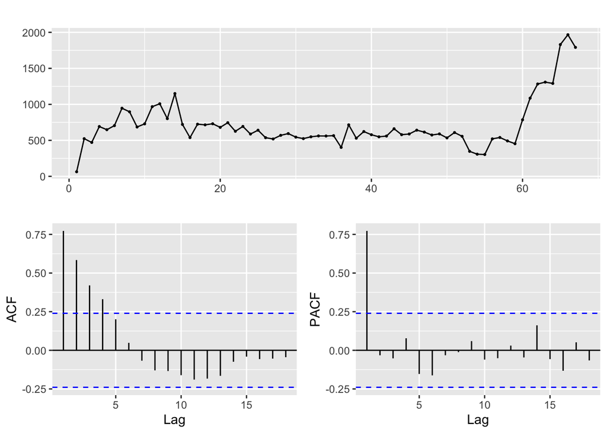

```r
General_Ads <- ts(data$general_ads, frequency = 1, start = c(1, 1))

#trend plot and ACF and PACF.
ggtsdisplay(General_Ads)
```

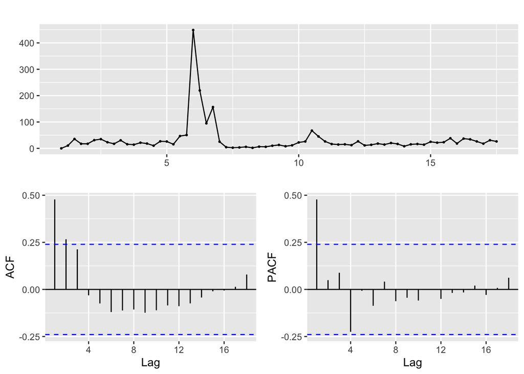

```r
Brand_Ads <- ts(data$brand_ads, frequency = 4, start = c(1, 1))

#trend plot and ACF and PACF.
ggtsdisplay(Brand_Ads)
```

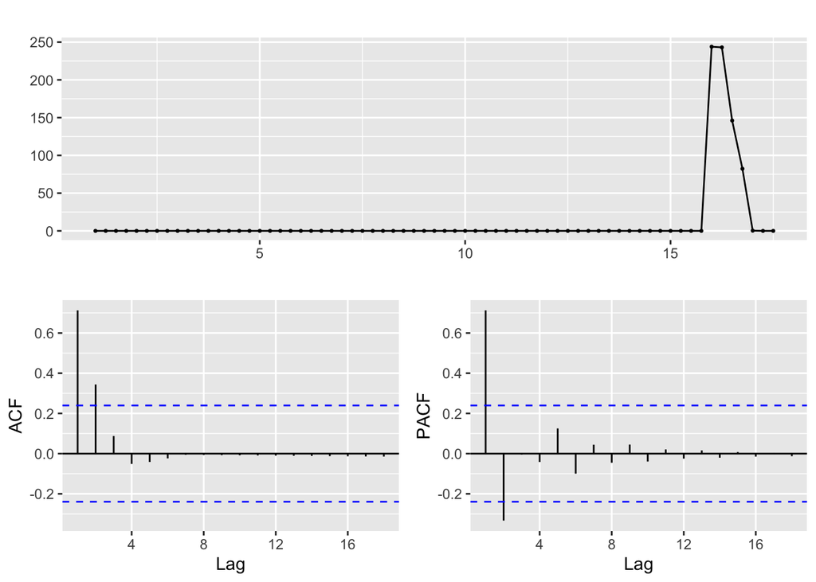

```r
Display_Ads <- ts(data$display_ads, frequency = 4, start = c(1, 1))

#trend plot and ACF and PACF.
ggtsdisplay(Display_Ads)
```

Based on the adf plots, it seems that only the General ads show non-stationary trends. We test all of these using the adf test:

```r
LgmvTotal <- ts(data$log_adjusted_gmv_total, frequency = 1, start = c(1, 1))
LgeneralAds <- ts(data$log_general_ads, frequency = 1, start = c(1, 1))
LbrandAds <- ts(data$log_brand_ads, frequency = 1, start = c(1, 1))
LdisplayAds <- ts(data$log_display_ads, frequency = 1, start = c(1, 1))


adf.test(LgmvTotal)
```

```
##
##  Augmented Dickey-Fuller Test
##
## data:  LgmvTotal
## Dickey-Fuller = 2.0515, Lag order = 4, p-value = 0.99
## alternative hypothesis: stationary
```

```r
adf.test(LgeneralAds)
```

```
##
##  Augmented Dickey-Fuller Test
##
## data:  LgeneralAds
## Dickey-Fuller = -0.48055, Lag order = 4, p-value = 0.98
## alternative hypothesis: stationary
```

```r
adf.test(LbrandAds)
```

```
##
##  Augmented Dickey-Fuller Test
##
## data:  LbrandAds
## Dickey-Fuller = -3.8297, Lag order = 4, p-value = 0.02268
## alternative hypothesis: stationary
```

```r
adf.test(LdisplayAds)
```

```
##
##  Augmented Dickey-Fuller Test
##
## data:  LdisplayAds
## Dickey-Fuller = -1.8237, Lag order = 4, p-value = 0.6466
## alternative hypothesis: stationary
```

The test results indicate that only the Brand search is stationary. Therefore, we will need to perform difference transformations to the other time series

```r
DgmvTotal <-diff(data$log_adjusted_gmv_total, differences = 1)
DgeneralAds <-diff(data$log_general_ads, differences = 1)
DdisplayAds <-diff(data$log_display_ads, differences = 1)

adf.test(DgmvTotal)
```

```
##
##  Augmented Dickey-Fuller Test
##
## data:  DgmvTotal
## Dickey-Fuller = 0.25344, Lag order = 4, p-value = 0.99
## alternative hypothesis: stationary
```

```r
adf.test(DgeneralAds)
```

```
##
##  Augmented Dickey-Fuller Test
##
## data:  DgeneralAds
## Dickey-Fuller = -3.7555, Lag order = 4, p-value = 0.027
## alternative hypothesis: stationary
```

```r
adf.test(DdisplayAds)
```

```
##
##  Augmented Dickey-Fuller Test
##
## data:  DdisplayAds
## Dickey-Fuller = -5.319, Lag order = 4, p-value = 0.01
## alternative hypothesis: stationary
```

```r
D2gmvTotal <-diff(data$log_adjusted_gmv_total, differences = 2)

adf.test(D2gmvTotal)
```

```
##
##  Augmented Dickey-Fuller Test
##
## data:  D2gmvTotal
## Dickey-Fuller = -4.032, Lag order = 3, p-value = 0.01386
## alternative hypothesis: stationary
```

### Construct a VAR model

Let’s start with a VAR model for the Total GMV

```r
DdisplayAds_cut <- window(DdisplayAds,start=2)
DgeneralAds_cut <- window(DgeneralAds, start=2)
LbrandAds_cut <- window(LbrandAds, start=3)
D2gmvTotal_ts <- ts(D2gmvTotal, frequency=1)

#Build the first dataset for VAR model
data.ts.d1 <- cbind(DdisplayAds_cut, DgeneralAds_cut, LbrandAds_cut,
                           D2gmvTotal_ts)

# Remove NA's
data.ts.d1 <- replace(data.ts.d1, is.na(data.ts.d1), 0)

var_total <- VAR(data.ts.d1, ic="AIC", lag.max=1, type="const")

lmp <- var_total$varresult

#stargazer( lmp$DdisplayAds_cut, lmp$DgeneralAds_cut,
#           lmp$LbrandAds_cut, lmp$D2gmvTotal_ts,
           # column.labels = c('Display', 'General', 'Brand', 'GMV'),
#           type = "text", dep.var.labels.include = FALSE )

stargazer(lmp, type='text')
```

```
##
## =================================================================
##                                       Dependent variable:
##                               -----------------------------------
##                                                y
##                                 (1)     (2)      (3)       (4)
## -----------------------------------------------------------------
## DdisplayAds_cut.l1             0.062   0.015   -0.070    -0.391
##                               (0.128) (0.032)  (0.101)   (0.286)
##
## DgeneralAds_cut.l1            1.037** -0.182    0.338     0.884
##                               (0.514) (0.127)  (0.409)   (1.153)
##
## LbrandAds_cut.l1              -0.043  -0.024  0.637***   -0.068
##                               (0.107) (0.026)  (0.085)   (0.240)
##
## D2gmvTotal_ts.l1               0.016  -0.006    0.050   -0.518***
##                               (0.048) (0.012)  (0.038)   (0.107)
##
## const                          0.107   0.092  1.121***    0.172
##                               (0.334) (0.083)  (0.265)   (0.748)
##
## -----------------------------------------------------------------
## Observations                    66      66       66        66
## R2                             0.069   0.050    0.491     0.352
## Adjusted R2                    0.008  -0.013    0.457     0.309
## Residual Std. Error (df = 61)  0.858   0.212    0.682     1.922
## F Statistic (df = 4; 61)       1.133   0.795  14.691*** 8.275***
## =================================================================
## Note:                                 *p<0.1; **p<0.05; ***p<0.01
```

### IRF Analysis[^1]

First, let’s have a look at the graphs. IRF plots help you see visually when the peak effects occur. On the plots, the black, solid line refers to IRF coefficients, while the red, dashed lines refer to lower and upper bound of the IRF coefficient’s confidence interval.

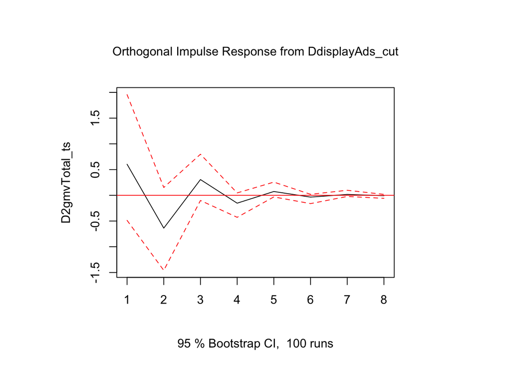

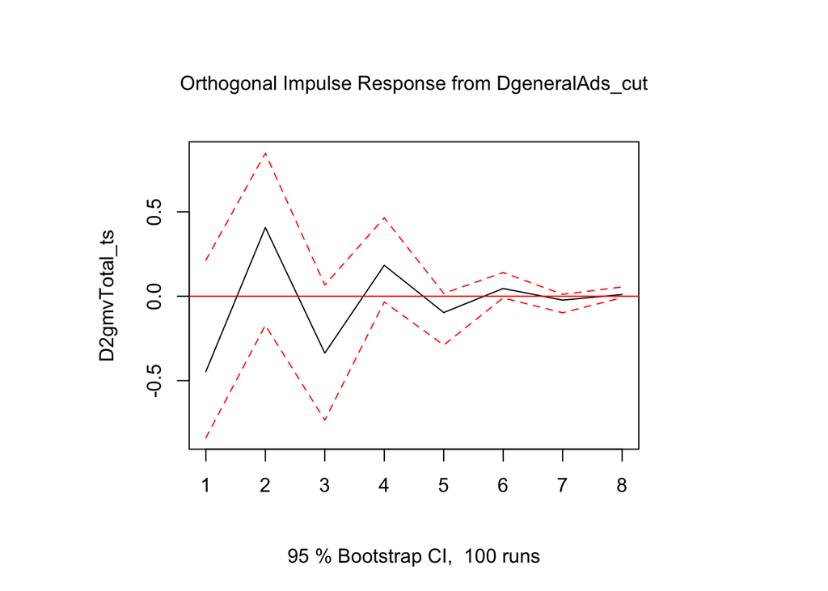

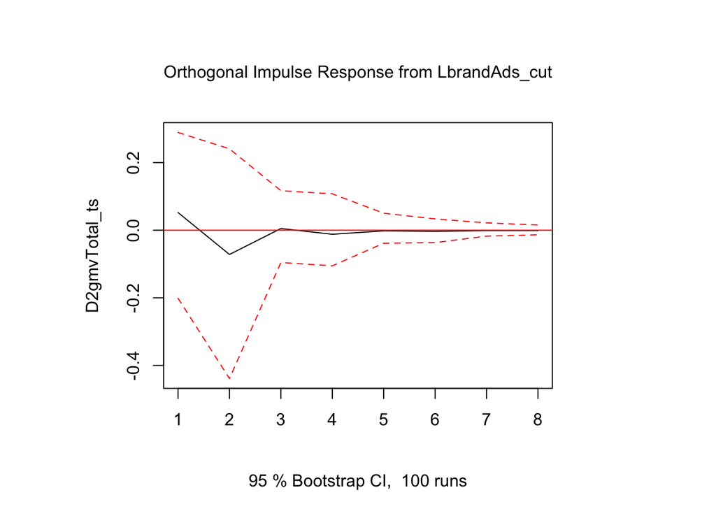

```r
irfs <- irf(var_total, impulse = c('DdisplayAds_cut', 'DgeneralAds_cut',
                                   'LbrandAds_cut'),
            response = 'D2gmvTotal_ts',
            runs = 100, n.ahead = 7 , ortho = TRUE, ci=0.95)
plot(irfs)
```

**Immediate and Long-Term Effects**